# Downloading Data:

```python
!pip install kaggle
```

[output not shown]

```python
!python -m pip install --upgrade pip
```

[output not shown]

[output cut: 22 more lines]

[output not shown]

```python
import os
```

```python
os.environ['KAGGLE_CONFIG_DIR'] = '.'
```

```python
!kaggle competitions download -c quora-insincere-questions-classification -f train.csv -p data
!kaggle competitions download -c quora-insincere-questions-classification -f test.csv -p data
!kaggle competitions download -c quora-insincere-questions-classification -f sample_submission.csv -p data
```

```
Downloading train.csv.zip to data
```

[output not shown]

# Exploring Data:

```python
import pandas as pd
```

```python
train_fname = './data/train.csv.zip'
test_fname = './data/test.csv.zip'
sample_fname = './data/sample_submission.csv.zip'
```

```python
raw_train_df = pd.read_csv(train_fname)
raw_test_df = pd.read_csv(test_fname)
sample_df = pd.read_csv(sample_fname)
```

```python
raw_train_df.head()
```

|  | qid | question_text | target |
| --- | --- | --- | --- |
| 0 | 00002165364db923c7e6 | How did Quebec nationalists see their province... | 0 |
| 1 | 000032939017120e6e44 | Do you have an adopted dog, how would you enco... | 0 |
| 2 | 0000412ca6e4628ce2cf | Why does velocity affect time? Does velocity a... | 0 |
| 3 | 000042bf85aa498cd78e | How did Otto von Guericke used the Magdeburg h... | 0 |
| 4 | 0000455dfa3e01eae3af | Can I convert montra helicon D to a mountain b... | 0 |

```python
raw_train_df['target'].value_counts(normalize=True)
```

```
target
0    0.93813
1    0.06187
Name: proportion, dtype: float64
```

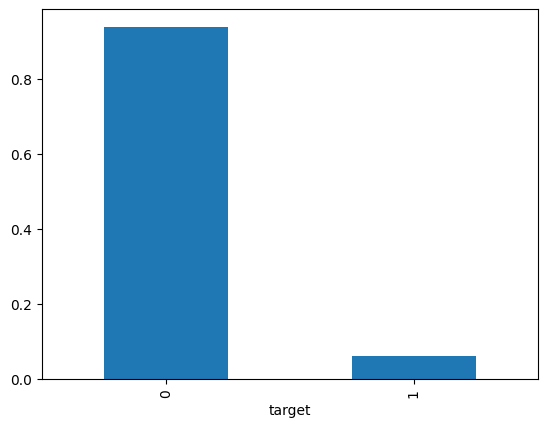

```python
raw_train_df['target'].value_counts(normalize=True).plot(kind='bar')
```

```python
sincere_df = raw_train_df[raw_train_df['target']==0].copy()
insincere_df = raw_train_df[raw_train_df['target']==1].copy()
```

```python
sincere_df['question_text'].values[:10]
```

```
array(['How did Quebec nationalists see their province as a nation in the 1960s?',
       'Do you have an adopted dog, how would you encourage people to adopt and not shop?',
       'Why does velocity affect time? Does velocity affect space geometry?',
       'How did Otto von Guericke used the Magdeburg hemispheres?',
       'Can I convert montra helicon D to a mountain bike by just changing the tyres?',
       'Is Gaza slowly becoming Auschwitz, Dachau or Treblinka for Palestinians?',
       'Why does Quora automatically ban conservative opinions when reported, but does not do the same for liberal views?',
       'Is it crazy if I wash or wipe my groceries off? Germs are everywhere.',
       'Is there such a thing as dressing moderately, and if so, how is that different than dressing modestly?',
       'Is it just me or have you ever been in this phase wherein you became ignorant to the people you once loved, completely disregarding their feelings/lives so you get to have something go your way and feel temporarily at ease. How did things change?'],
      dtype=object)
```

```python
insincere_df['question_text'].values[:10]
```

```
array(['Has the United States become the largest dictatorship in the world?',
       'Which babies are more sweeter to their parents? Dark skin babies or light skin babies?',
       "If blacks support school choice and mandatory sentencing for criminals why don't they vote Republican?",
       'I am gay boy and I love my cousin (boy). He is sexy, but I dont know what to do. He is hot, and I want to see his di**. What should I do?',
       'Which races have the smallest penis?',
       'Why do females find penises ugly?',
       'How do I marry an American woman for a Green Card? How much do they charge?',
       "Why do Europeans say they're the superior race, when in fact it took them over 2,000 years until mid 19th century to surpass China's largest economy?",
       'Did Julius Caesar bring a tyrannosaurus rex on his campaigns to frighten the Celts into submission?',
       "In what manner has Republican backing of 'states rights' been hypocritical and what ways have they actually restricted the ability of states to make their own laws?"],
      dtype=object)
```

```python
raw_test_df
```

|  | qid | question_text |
| --- | --- | --- |
| 0 | 0000163e3ea7c7a74cd7 | Why do so many women become so rude and arroga... |
| 1 | 00002bd4fb5d505b9161 | When should I apply for RV college of engineer... |
| 2 | 00007756b4a147d2b0b3 | What is it really like to be a nurse practitio... |
| 3 | 000086e4b7e1c7146103 | Who are entrepreneurs? |
| 4 | 0000c4c3fbe8785a3090 | Is education really making good people nowadays? |
| ... | ... | ... |
| 375801 | ffff7fa746bd6d6197a9 | How many countries listed in gold import in in... |
| 375802 | ffffa1be31c43046ab6b | Is there an alternative to dresses on formal p... |
| 375803 | ffffae173b6ca6bfa563 | Where I can find best friendship quotes in Tel... |
| 375804 | ffffb1f7f1a008620287 | What are the causes of refraction of light? |
| 375805 | fffff85473f4699474b0 | Climate change is a worrying topic. How much t... |

375806 rows × 2 columns

```python
sample_df
```

|  | qid | prediction |
| --- | --- | --- |
| 0 | 0000163e3ea7c7a74cd7 | 0 |
| 1 | 00002bd4fb5d505b9161 | 0 |
| 2 | 00007756b4a147d2b0b3 | 0 |
| 3 | 000086e4b7e1c7146103 | 0 |
| 4 | 0000c4c3fbe8785a3090 | 0 |
| ... | ... | ... |
| 375801 | ffff7fa746bd6d6197a9 | 0 |
| 375802 | ffffa1be31c43046ab6b | 0 |
| 375803 | ffffae173b6ca6bfa563 | 0 |
| 375804 | ffffb1f7f1a008620287 | 0 |
| 375805 | fffff85473f4699474b0 | 0 |

375806 rows × 2 columns

# Text Preprocessing Technique:

### TF-IDF (Term Frequency-Inverse Document Frequency):

TF-IDF is a feature extraction technique for textual data. It not only converts documents or text into vectors of numeric values by means of count but aims to capture the importance of words in a collection of documents, so that we can feed the meaningful representation of text into Machine Learning model. Machine Learning models cannot process text directly that's why we first need to convert to have fixed length input for modeling. Here's a step-by-step explanation:

1. **Term Frequency (TF):**  
   Term Frequency (TF) provides information about the local importance of a word within a single document by measuring how often a word appears in a specific document. It is calculated using the formula:

TF(word, document) = (Number of times the word appears in the document) / (Total number of words in the document)

2. **Inverse Document Frequency (IDF):**  
   Inverse Document Frequency (IDF) quantifies how unique or important a word is across the entire corpus of documents by emphasizing words that appear in fewer documents, giving higher weights to rare and distinctive words. It's calculated using the formula:

IDF(word) = log((Total number of documents) / (Number of documents containing the word))

3. **TF-IDF Calculation:**  
   The TF-IDF score for a word in a document is the product of its Term Frequency (TF) and Inverse Document Frequency (IDF). The resulting value reflects how important a word is in a particular document relative to its occurrence across the entire corpus.

TF-IDF(word, document) = TF(word, document) * IDF(word)

**Comparison with Bag of Words (BoW):**

- Handling of Word Importance: BoW only considers the presence or absence of words and their counts in documents.TF-IDF takes into account both the frequency of a word within a document (TF) and its rarity across the entire corpus (IDF), providing a more nuanced representation of word importance.
- Impact of Common Words: BoW representation can give high weights to common words (e.g., "the," "and") that appear frequently across documents. TF-IDF reduces the weight of common words by factoring in their inverse document frequency.
- Handling of Rare Words: BoW doesn't distinguish rare words from common ones, treating all words equally. TF-IDF gives higher weights to rare words, as their IDF values are higher.
- Sparsity: BoW vectors represent documents as counts of individual words. Since most documents won't contain all the words in the vocabulary, BoW vectors are often sparse due to the many zero-count entries. TF-IDF vectors attempt to weigh words based on their importance in a document relative to the entire corpus. However, if a word is not present in a document (TF = 0), its TF-IDF score for that document will indeed be 0, regardless of its IDF. This can result in sparse TF-IDF vectors, similar to BoW vectors.
- Contextual Information: BoW completely discards word order and context, treating documents as bags of words. TF-IDF retains some context information by considering both the local (TF) and global (IDF) significance of words.

In summary, while both BoW and TF-IDF are methods for converting text into numerical representations, TF-IDF provides a more refined approach by considering the importance of words in both local and global contexts. It addresses some of the limitations of BoW and offers more meaningful representations, especially when dealing with larger corpora and documents.

```python
import nltk
```

```python
# word tokenizer
from nltk import word_tokenize
nltk.download('punkt')
```

```
True
```

```python
# getting list of english stopwords
from nltk.corpus import stopwords

nltk.download('stopwords')
en_stopwords = stopwords.words('english')
```

```python
# creating stemmer object
from nltk.stem import SnowballStemmer
stemmer = SnowballStemmer(language="english")
```

```python
from sklearn.feature_extraction.text import TfidfVectorizer
```

```python
def tokenize_and_stem(text):
    return [stemmer.stem(token) for token in word_tokenize(text)]
```

```python
# creating count vectorizer object with configuration to incorporate preprocessing techniques together
vectorizer = TfidfVectorizer(lowercase=True,
                             stop_words=en_stopwords, #removing stopwords
                             tokenizer=tokenize_and_stem, #tokenization and stemming at the same time
                             ngram_range=(1, 2)
                             )
```

```python
%%time
vectorizer.fit(raw_train_df['question_text'])
```

```
CPU times: total: 3min 24s
Wall time: 3min 25s
```

```
TfidfVectorizer(ngram_range=(1, 2),
                stop_words=['i', 'me', 'my', 'myself', 'we', 'our', 'ours',
                            'ourselves', 'you', "you're", "you've", "you'll",
                            "you'd", 'your', 'yours', 'yourself', 'yourselves',
                            'he', 'him', 'his', 'himself', 'she', "she's",
                            'her', 'hers', 'herself', 'it', "it's", 'its',
                            'itself', ...],
                tokenizer=<function tokenize_and_stem at 0x000002CCCB7F07C0>)
```

```python
len(vectorizer.vocabulary_)
```

```
3350230
```

```python
vectorizer.get_feature_names_out()[:100]
```

```
array(['\x02tñ\x7f¼é\x1aaùõ\x8d¶rwìiìñó',
       '\x02tñ\x7f¼é\x1aaùõ\x8d¶rwìiìñó \x10œø', '\x10i', '\x10i want',
       '\x10new', '\x10new york', '\x10œø', '\x10œø <', '\x17',
       '\x17 y.¾ƒe', '!', '! !', '! #', '! %', '! &', "! '", "! ''",
       "! 'm", "! 's", '! (', '! )', '! +', '! +2', '! +20', '! +24',
       '! +26', '! +2·2', '! +3', '! +30', '! +3·3', '! +40', '! +50',
       '! +…', '! +…+50·50', '! +…+999', '! +…to', '! ,', '! -', '! .',
       '! ..', '! /', '! /101', '! /dx', '! /n^n', '! 0', '! 1', '! 10th',
       '! 19', '! 2018', '! 29', '! 3', '! 39', '! 4,444', '! 45', '! 5',
       '! 5d', '! 8', '! :', '! <', '! =', '! =-1', '! =1', '! =3',
       '! =3×2×1', '! =6', '! ==', '! =o', '! =x', '! =x^y+y^x', '! ?',
       '! @', '! \\', '! \\cdot', '! \\frac', '! \\right', '! \\sqrt',
       '! \\u0001f62d', '! ]', '! ^', '! _blahblah',
       '! _i_feel_like_a_woman', '! ``', '! a++', '! aargh', '! absurd',
       '! accident', '! accomplish', '! act', '! affect', '! agre',
       '! ahaahahaha', '! air', '! ajax', '! allah', '! allow', '! also',
       '! american', '! anbodi', '! ani', '! anim'], dtype=object)
```

```python
%%time
model_inputs = vectorizer.transform(raw_train_df['question_text'])
```

```
CPU times: total: 3min 28s
Wall time: 3min 29s
```

```python
model_inputs.shape
```

```
(1306122, 3350230)
```

```python
model_inputs
```

```
<1306122x3350230 sparse matrix of type '<class 'numpy.float64'>'
	with 19934440 stored elements in Compressed Sparse Row format>
```

```python
raw_train_df['question_text'].values[0]
```

```
'How did Quebec nationalists see their province as a nation in the 1960s?'
```

```python
model_inputs[0].toarray()
```

```
array([[0., 0., 0., ..., 0., 0., 0.]])
```

```python
%%time
test_inputs = vectorizer.transform(raw_test_df['question_text'])
```

```
CPU times: total: 58.1 s
Wall time: 58.3 s
```

# Model Training:

```python
# Splitting data into train_set & validation_set
from sklearn.model_selection import train_test_split
```

```python
train_inputs, valid_inputs, train_target, valid_target = train_test_split(model_inputs, raw_train_df['target'], test_size=0.3, random_state=42)
```

```python
train_inputs.shape, valid_inputs.shape
```

```
((914285, 3350230), (391837, 3350230))
```

```python
train_target.shape, valid_target.shape
```

```
((914285,), (391837,))
```

```python
train_target.value_counts(normalize=True)
```

```
target
0    0.937715
1    0.062285
Name: proportion, dtype: float64
```

```python
valid_target.value_counts(normalize=True)
```

```
target
0    0.939097
1    0.060903
Name: proportion, dtype: float64
```

### Logistic Regression Model:

```python
from sklearn.linear_model import LogisticRegression
```

```python
MAX_ITER = 1000
```

```python
log_reg_model = LogisticRegression(max_iter=MAX_ITER)
```

```python
%%time
log_reg_model.fit(train_inputs, train_target)
```

```
CPU times: total: 3min 54s
Wall time: 2min 31s
```

```
LogisticRegression(max_iter=1000)
```

```python
valid_preds = log_reg_model.predict(valid_inputs)
```

```python
from sklearn.metrics import accuracy_score, precision_score, recall_score, f1_score
```

```python
valid_accuracy = accuracy_score(valid_target, valid_preds)
valid_precision = precision_score(valid_target, valid_preds)
valid_recall = recall_score(valid_target, valid_preds)
valid_f1 = f1_score(valid_target, valid_preds)
```

```python
valid_accuracy, valid_precision, valid_recall, valid_f1
```

```
(0.9526027404252279,
 0.7175986842105263,
 0.3656553804894402,
 0.4844548079058406)
```

```python
valid_accuracy, valid_precision, valid_recall, valid_f1
```

[output not shown]

```python
import numpy as np
```

```python
random_preds = np.random.choice((0, 1), len(valid_target))
```

```python
random_accuracy = accuracy_score(valid_target, random_preds)
random_f1 = f1_score(valid_target, random_preds)
```

```python
random_accuracy, random_f1
```

```
(0.5012084106401387, 0.10913947372019564)
```

# Conclusion:

The aim of this notebook is to walkthrough you the TF-IDF (text processing techniques) as comapre to the BoW which we covered in last notebook. I'll continue from here to upwards till advanced NLP techniques, models etc. Modeling part done here is basic one, just to show how can Machine Learning models be used to train on text data.